# Encontrando doadores para a *CharityML*

#### Udacity - Nanodegree Engenheiro de Machine Learning - Aprendizado Supervisionado

## CharityML

> CharityML é uma instituição de caridade fictícia localizada no centro do Vale do Silício, que foi criada para dar apoio financeiro a pessoas que querem aprender machine learning. Após quase 32.000 cartas enviadas a pessoas da comunidade, a CharityML determinou que todas as doações recebidas vieram de pessoas que ganham mais do que U$50,000 por ano. Para expandir sua base de doadores potenciais, a CharityML decidiu enviar cartas aos residentes da Califórnia, mas apenas àqueles com maior probabilidade de fazer doações. Com quase 15 milhões de trabalhadores na Califórnia, a CharityML pediu ajuda na criação de um algoritmo que melhor identifique potenciais doadores e reduza o custo com o envio de cartas. Este tipo de tarefa pode surgir em organizações sem fins lucrativos que sobrevivem de doações. Entender a remuneração de um indivíduo pode ajudar a organização o montante mais adequado para uma solicitação de doação, ou ainda se eles realmente deveriam entrar em contato com a pessoa. Enquanto pode ser uma tarefa difícil determinar a faixa de renda de uma pesssoa de maneira direta, nós podemos inferir estes valores através de outros recursos disponíveis publicamente.

## Visão geral do projeto

Neste projeto, apliquei técnicas de aprendizagem supervisionada e raciocínio analítico sobre os dados coletados pelo censo dos Estados Unidos, afim de ajudar a CharityML (uma instituição de caridade fictícia) a identificar as pessoas com maior probabilidade de doar à causa deles. Primeiro, foi feito uma exploração para saber como os dados do censo são gravados. Em seguida, apliquei uma série de transformações e técnicas de pré-processamento para manipular os dados e organizá-los em um formato com o qual precisei trabalhar. Depois, avaliei vários modelos de aprendizagem supervisionada de minha escolha sobre os dados, para definir qual é o mais adequado para a solução. Por último, otimizei o modelo selecionado e o apresentei para os avaliadores da Udacity como solução para a CharityML.

## Explorando os dados

O conjunto de dados para este projeto se origina do [Repositório de Machine Learning UCI](https://archive.ics.uci.edu/ml/datasets/Census+Income) e foi cedido por Ron Kohavi e Barry Becker, após a sua publicação no artigo *"Scaling Up the Accuracy of Naive-Bayes Classifiers: A Decision-Tree Hybrid"*. Você pode encontrar o artigo de Ron Kohavi [online](https://www.aaai.org/Papers/KDD/1996/KDD96-033.pdf). Os dados que investigaremos aqui possuem algumas pequenas modificações se comparados com os dados originais, como por exemplo a remoção da funcionalidade `'fnlwgt'` e a remoção de registros inconsistentes.

Perceba que a última coluna deste cojunto de dados, `'income'`, será o rótulo do nosso alvo (se um indivíduo possui remuneração igual ou maior do que $50,000 anualmente). Todas as outras colunas são dados de cada indívduo na base de dados do censo.

**Explorando as colunas**

- **age**: contínuo.
- **workclass**: Private, Self-emp-not-inc, Self-emp-inc, Federal-gov, Local-gov, State-gov, Without-pay, Never-worked.
- **education**: Bachelors, Some-college, 11th, HS-grad, Prof-school, Assoc-acdm, Assoc-voc, 9th, 7th-8th, 12th, Masters, 1st-4th, 10th, Doctorate, 5th-6th, Preschool.
- **education-num**: contínuo.
- **marital-status**: Married-civ-spouse, Divorced, Never-married, Separated, Widowed, Married-spouse-absent, Married-AF-spouse.
- **occupation**: Tech-support, Craft-repair, Other-service, Sales, Exec-managerial, Prof-specialty, Handlers-cleaners, Machine-op-inspct, Adm-clerical, Farming-fishing, Transport-moving, Priv-house-serv, Protective-serv, Armed-Forces.
- **relationship**: Wife, Own-child, Husband, Not-in-family, Other-relative, Unmarried.
- **race**: Black, White, Asian-Pac-Islander, Amer-Indian-Eskimo, Other.
- **sex**: Female, Male.
- **capital-gain**: contínuo.
- **capital-loss**: contínuo.
- **hours-per-week**: contínuo.
- **native-country**: United-States, Cambodia, England, Puerto-Rico, Canada, Germany, Outlying-US(Guam-USVI-etc), India, Japan, Greece, South, China, Cuba, Iran, Honduras, Philippines, Italy, Poland, Jamaica, Vietnam, Mexico, Portugal, Ireland, France, Dominican-Republic, Laos, Ecuador, Taiwan, Haiti, Columbia, Hungary, Guatemala, Nicaragua, Scotland, Thailand, Yugoslavia, El-Salvador, Trinadad&Tobago, Peru, Hong, Holand-Netherlands.

```python
# Importa as bibliotecas necessárias para o projeto.
import numpy as np
import pandas as pd
from time import time
from IPython.display import display # Permite a utilização da função display() para DataFrames.

# Importação da biblioteca de visualização visuals.py
import visuals as vs

# Exibição amigável para notebooks
%matplotlib inline

# Carregando os dados do Censo
data = pd.read_csv("census.csv")

# Sucesso - Exibindo o primeiro registro
display(data.head(n=1))
```

|  | age | workclass | education_level | education-num | marital-status | occupation | relationship | race | sex | capital-gain | capital-loss | hours-per-week | native-country | income |
| --- | --- | --- | --- | --- | --- | --- | --- | --- | --- | --- | --- | --- | --- | --- |
| 0 | 39 | State-gov | Bachelors | 13.0 | Never-married | Adm-clerical | Not-in-family | White | Male | 2174.0 | 0.0 | 40.0 | United-States | <=50K |

### Implementação: Explorando os Dados

Uma investigação superficial da massa de dados determinará quantos indivíduos se enquadram em cada grupo e nos dirá sobre o percentual destes indivúdos com remuneração anual superior à \$50,000.

```python
# checa possíveis valores categoricos
data['income'].value_counts()
```

```
<=50K    34014
>50K     11208
Name: income, dtype: int64
```

```python
# Número total de registros.
n_records = len(data)

# Número de registros com remuneração anual superior à $50,000
n_greater_50k = len(data[data.income == '>50K'])

# O número de registros com remuneração anual até $50,000
n_at_most_50k = len(data[data.income == '<=50K'])

# O percentual de indivíduos com remuneração anual superior à $50,000
greater_percent = n_greater_50k * 100 / n_records

# Exibindo os resultados
print("Total number of records: {}".format(n_records))
print("Individuals making more than $50,000: {}".format(n_greater_50k))
print("Individuals making at most $50,000: {}".format(n_at_most_50k))
print("Percentage of individuals making more than $50,000: {:.2f}%".format(greater_percent))
```

```
Total number of records: 45222
Individuals making more than $50,000: 11208
Individuals making at most $50,000: 34014
Percentage of individuals making more than $50,000: 24.78%
```

## Preparando os dados

Antes de que os dados possam ser utilizados como input para algoritmos de machine learning, muitas vezes eles precisam ser tratados, formatados e reestruturados — este processo é conhecido como **pré-processamento**. Felizmente neste conjunto de dados não existem registros inconsistentes para tratamento, porém algumas colunas precisam ser ajustadas. Este pré-processamento pode ajudar muito com o resultado e poder de predição de quase todos os algoritmos de aprendizado.

### Transformando os principais desvios das colunas contínuas

Um conjunto de dados pode conter ao menos uma coluna onde os valores tendem a se próximar para um único número, mas também podem conter registros com o mesmo atributo contendo um valor muito maior ou muito menor do que esta tendência. Algoritmos podem ser sensíveis para estes casos de distribuição de valores e este fator pode prejudicar sua performance se a distribuição não estiver normalizada de maneira adequada. Com o conjunto de dados do censo, dois atributos se encaixam nesta descrição: '`capital-gain'` e `'capital-loss'`.

Visualizando as distribuição destes valores.

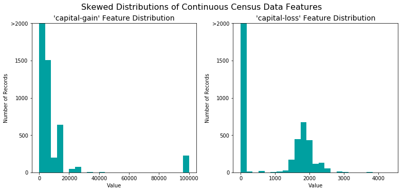

```python
# Dividindo os dados entre features e coluna alvo
income_raw = data['income']
features_raw = data.drop('income', axis = 1)

# Visualizando os principais desvios das colunas contínuas entre os dados
vs.distribution(data)
```

Para atributos com distribuição muito distorcida, tais como `'capital-gain'` e `'capital-loss'`, é uma prática comum aplicar uma transformação logarítmica nos dados para que os valores muito grandes e muito pequenos não afetem a performance do algoritmo de aprendizado. Usar a transformação logarítmica reduz significativamente os limites dos valores afetados pelos outliers (valores muito grandes ou muito pequenos). Deve-se tomar cuidado ao aplicar esta transformação, poir o logaritmo de `0` é indefinido, portanto temos que incrementar os valores em uma pequena quantia acima de `0` para aplicar o logaritmo adequadamente.

Execute o código da célula abaixo para realizar a transformação nos dados e visualizar os resultados. De novo, note os valores limite e como os valores estão distribuídos.

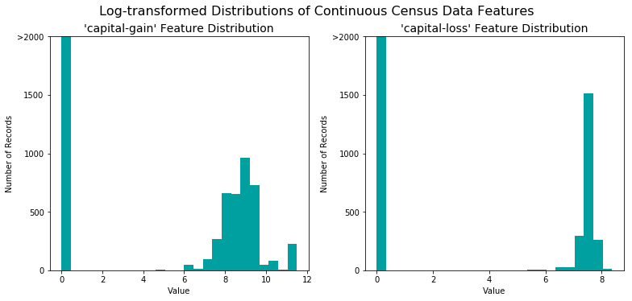

```python
# Aplicando a transformação de log nos registros distorcidos.
skewed = ['capital-gain', 'capital-loss']
features_log_transformed = pd.DataFrame(data = features_raw)
features_log_transformed[skewed] = features_raw[skewed].apply(lambda x: np.log(x + 1))

# Visualizando as novas distribuições após a transformação.
vs.distribution(features_log_transformed, transformed = True)
```

```python
features_log_transformed.head()
```

|  | age | workclass | education_level | education-num | marital-status | occupation | relationship | race | sex | capital-gain | capital-loss | hours-per-week | native-country |
| --- | --- | --- | --- | --- | --- | --- | --- | --- | --- | --- | --- | --- | --- |
| 0 | 39 | State-gov | Bachelors | 13.0 | Never-married | Adm-clerical | Not-in-family | White | Male | 7.684784 | 0.0 | 40.0 | United-States |
| 1 | 50 | Self-emp-not-inc | Bachelors | 13.0 | Married-civ-spouse | Exec-managerial | Husband | White | Male | 0.000000 | 0.0 | 13.0 | United-States |
| 2 | 38 | Private | HS-grad | 9.0 | Divorced | Handlers-cleaners | Not-in-family | White | Male | 0.000000 | 0.0 | 40.0 | United-States |
| 3 | 53 | Private | 11th | 7.0 | Married-civ-spouse | Handlers-cleaners | Husband | Black | Male | 0.000000 | 0.0 | 40.0 | United-States |
| 4 | 28 | Private | Bachelors | 13.0 | Married-civ-spouse | Prof-specialty | Wife | Black | Female | 0.000000 | 0.0 | 40.0 | Cuba |

### Normalizando atributos numéricos

Além das transformações em atributos distorcidos, é uma boa prática comum realizar algum tipo de adaptação de escala nos atributos numéricos. Ajustar a escala nos dados não modifica o formato da distribuição de cada coluna (tais como `'capital-gain'` ou `'capital-loss'` acima); no entanto, a normalização garante que cada atributo será tratado com o mesmo peso durante a aplicação de aprendizado supervisionado. Note que uma vez aplicada a escala, a observação dos dados não terá o significado original, como exemplificado abaixo.

Execute o código da célula abaixo para normalizar cada atributo numérico, nós usaremos ara isso a [`sklearn.preprocessing.MinMaxScaler`](http://scikit-learn.org/stable/modules/generated/sklearn.preprocessing.MinMaxScaler.html).

```python
# Importando sklearn.preprocessing.StandardScaler
from sklearn.preprocessing import MinMaxScaler

# Inicializando um aplicador de escala e aplicando em seguida aos atributos
scaler = MinMaxScaler() # default=(0, 1)
numerical = ['age', 'education-num', 'capital-gain', 'capital-loss', 'hours-per-week']

features_log_minmax_transform = pd.DataFrame(data = features_log_transformed)
features_log_minmax_transform[numerical] = scaler.fit_transform(features_log_transformed[numerical])

# Exibindo um exemplo de registro com a escala aplicada
display(features_log_minmax_transform.head(n=5))
```

|  | age | workclass | education_level | education-num | marital-status | occupation | relationship | race | sex | capital-gain | capital-loss | hours-per-week | native-country |
| --- | --- | --- | --- | --- | --- | --- | --- | --- | --- | --- | --- | --- | --- |
| 0 | 0.301370 | State-gov | Bachelors | 0.800000 | Never-married | Adm-clerical | Not-in-family | White | Male | 0.667492 | 0.0 | 0.397959 | United-States |
| 1 | 0.452055 | Self-emp-not-inc | Bachelors | 0.800000 | Married-civ-spouse | Exec-managerial | Husband | White | Male | 0.000000 | 0.0 | 0.122449 | United-States |
| 2 | 0.287671 | Private | HS-grad | 0.533333 | Divorced | Handlers-cleaners | Not-in-family | White | Male | 0.000000 | 0.0 | 0.397959 | United-States |
| 3 | 0.493151 | Private | 11th | 0.400000 | Married-civ-spouse | Handlers-cleaners | Husband | Black | Male | 0.000000 | 0.0 | 0.397959 | United-States |
| 4 | 0.150685 | Private | Bachelors | 0.800000 | Married-civ-spouse | Prof-specialty | Wife | Black | Female | 0.000000 | 0.0 | 0.397959 | Cuba |

### Implementação: Pré-processamento dos dados

A partir da tabela em **Explorando os dados** acima, nós podemos observar que existem diversos atributos não-numéricos para cada registro. Usualmente, algoritmos de aprendizado esperam que os inputs sejam numéricos, o que requer que os atributos não numéricos (chamados de *variáveis de categoria*) sejam convertidos. Uma maneira popular de converter as variáveis de categoria é utilizar a estratégia **one-hot encoding**. Esta estratégia cria uma variável para cada categoria possível de cada atributo não numérico. Por exemplo, assuma que `algumAtributo` possuí três valores possíveis: `A`, `B`, ou `C`. Nós então transformamos este atributo em três novos atributos: `algumAtributo_A`, `algumAtributo_B` e `algumAtributo_C`.

|  | algumAtributo |  | algumAtributo_A | algumAtributo_B | algumAtributo_C |
| --- | --- | --- | --- | --- | --- |
| 0 | B |  | 0 | 1 | 0 |
| 1 | C | ----> one-hot encode ----> | 0 | 0 | 1 |
| 2 | A |  | 1 | 0 | 0 |

Além disso, assim como os atributos não-numéricos, precisaremos converter a coluna alvo não-numérica, `'income'`, para valores numéricos para que o algoritmo de aprendizado funcione. Uma vez que só existem duas categorias possíveis para esta coluna ("<=50K" e ">50K"), nós podemos evitar a utilização do one-hot encoding e simplesmente transformar estas duas categorias para `0` e `1`, respectivamente. No trecho de código abaixo, foi realizado as seguintes transformações:

```python
# Utiliza o one-hot encoding nos dados em 'features_log_minmax_transform' utilizando pandas.get_dummies()
features_final = pd.get_dummies(features_log_minmax_transform)

# Realiza o encode da coluna 'income_raw' para valores numéricos
income = income_raw.apply(lambda x: 0 if x == '<=50K' else 1)

# Exibe o número de colunas depois do one-hot encoding
encoded = list(features_final.columns)
print("{} total features after one-hot encoding.".format(len(encoded)))

# Exibe as colunas após o encode
# print(encoded)
```

```
103 total features after one-hot encoding.
```

### Embaralhar e dividir os dados

Agora todas as *variáveis de categoria* foram convertidas em atributos numéricos e todos os atributos numéricos foram normalizados. Como sempre, nós agora dividiremos os dados entre conjuntos de treinamento e de teste. 80% dos dados serão utilizados para treinamento e 20% para teste.

A célula abaixo realiza essa divisão.

```python
# Importar train_test_split
from sklearn.cross_validation import train_test_split

# Dividir os 'atributos' e 'income' entre conjuntos de treinamento e de testes.
X_train, X_test, y_train, y_test = train_test_split(features_final,
                                                    income,
                                                    test_size = 0.2,
                                                    random_state = 0)

# Mostra os resultados da divisão
print("Conjunto de treinamento possui {} amostras.".format(X_train.shape[0]))
print("Conjunto de teste possui {} amostras.".format(X_test.shape[0]))
```

```
Conjunto de treinamento possui 36177 amostras.
Conjunto de teste possui 9045 amostras.
```

## Avaliando a performance do modelo

Nesta seção nós investigaremos quatro algoritmos diferentes e determinaremos qual deles é melhor para a modelagem dos dados. Três destes algoritmos serão algoritmos de aprendizado supervisionado de sua escolha e o quarto algoritmo é conhecido como *naive predictor*.

### Métricas e o Naive predictor

*CharityML*, equpada com sua pesquisa, sabe que os indivíduos que fazem mais do que \$50,000 possuem maior probabilidade de doar para a sua campanha de caridade. Por conta disto, a *CharityML* está particularmente interessada em predizer com acurácia quais indivíduos possuem remuneração acima de \$50,000. Parece uqe utilizar **acurácia (accuracy)** como uma métrica para avaliar a performance de um modelo é um parâmetro adequado. Além disso, identificar alguém que *não possui* remuneração acima de \$50,000 como alguém que recebe acima deste valor seria ruim para a *CharityML*, uma vez que eles estão procurando por indivíduos que desejam doar. Com isso, a habilidade do modelo em predizer com preisão aqueles que possuem a remuneração acima dos \$50,000 é *mais importante* do que a habilidade de realizar o **recall** destes indivíduos. Nós podemos utilizar a fórmula **F-beta score** como uma métrica que considera ambos: precision e recall.

$$ F_{\beta} = (1 + \beta^2) \cdot \frac{precision \cdot recall}{\left( \beta^2 \cdot precision \right) + recall} $$

Em particular, quando $\beta = 0.5$, maior ênfase é atribuída para a variável precision. Isso é chamado de **F$_{0.5}$ score** (ou F-score, simplificando).

Analisando a distribuição de classes (aqueles que possuem remuneração até \$50,000 e aqueles que possuem remuneração superior), fica claro que a maioria dos indivíduos não possui remuneração acima de \$50,000. Isto pode ter grande impacto na **acurácia (accuracy)**, uma vez que nós poderíamos simplesmente dizer *"Esta pessoa não possui remuneração acima de \$50,000"* e estar certos em boa parte das vezes, sem ao menos olhar os dados! Fazer este tipo de afirmação seria chamado de **naive**, uma vez que não consideramos nenhuma informação para balisar este argumento. É sempre importante considerar a *naive prediction* para seu conjunto de dados, para ajudar a estabelecer um benchmark para análise da performance dos modelos. Com isso, sabemos que utilizar a naive prediction não traria resultado algum: Se a predição apontasse que todas as pessoas possuem remuneração inferior à \$50,000, a *CharityML* não identificaria ninguém como potencial doador.

#### Nota: Revisando: accuracy, precision e recall

**Accuracy** mede com que frequência o classificador faz a predição correta. É a proporção entre o número de predições corretas e o número total de predições (o número de registros testados).

**Precision** informa qual a proporção de mensagens classificamos como spam eram realmente spam. Ou seja, é a proporção de verdadeiros positivos (mensagens classificadas como spam que eram realmente spam) sobre todos os positivos (todas as palavras classificadas como spam, independente se a classificação estava correta), em outras palavras, é a proporção

`[Verdadeiros positivos/(Verdadeiros positivos + Falso positivos)]`

**Recall(sensibilidade)** nos informa qual a proporção das mensagens que eram spam que foram corretamente classificadas como spam. É a proporção entre os verdadeiros positivos (classificados como spam, que realmente eram spam) sobre todas as palavras que realmente eram spam. Em outras palavras, é a proporção entre

`[Verdadeiros positivos/(Verdadeiros positivos + Falso negativos)]`

Para problemas de classificação distorcidos em suas distribuições, como no nosso caso, por exemplo, se tivéssemos 100 mensagems de texto e apenas 2 fossem spam e todas as outras não fossem, a "accuracy" por si só não seria uma métrica tão boa. Nós poderiamos classificar 90 mensagems como "não-spam" (incluindo as 2 que eram spam mas que teriam sido classificadas como não-spam e, por tanto, seriam falso negativas.) e 10 mensagems como spam (todas as 10 falso positivas) e ainda assim teriamos uma boa pontuação de accuracy. Para estess casos, precision e recall são muito úteis. Estas duas métricas podem ser combinadas para resgatar o F1 score, que é calculado através da média(harmônica) dos valores de precision e de recall. Este score pode variar entre 0 e 1, sendo 1 o melhor resultado possível para o F1 score (consideramos a média harmônica pois estamos lidando com proporções).

### Performance do Naive Predictor

Se escolhessemos um modelo que sempre prediz que um indivíduo possui remuneração acima de $50,000, qual seria a accuracy e o F-score considerando este conjunto de dados?

**Por favor, note** que o propósito ao gerar um naive predictor é simplesmente exibir como um modelo sem nenhuma inteligência se comportaria. No mundo real, idealmente o seu modelo de base será o resultado de um modelo anterior ou poderia ser baseado em um paper no qual você se basearia para melhorar. Quando não houver qualquer benchmark de modelo, utilizar um naive predictor será melhor do que uma escolha aleatória.

```python
'''
TP = np.sum(income) # Contando pois este é o caso "naive". Note que 'income' são os dados 'income_raw' convertidos
para valores numéricos durante o passo de pré-processamento de dados.
FP = income.count() - TP # Específico para o caso naive

TN = 0 # Sem predições negativas para o caso naive
FN = 0 # Sem predições negativas para o caso naive
'''
# Calcular accuracy, precision e recall
TN = 0
FN = 0
TP = float(np.sum(income))
FP = float(income.count() - TP)
# Fórmula accuracy = [True Positive/(True Positives + False Positives)]
accuracy = TP/(TP + FP)
# Fórmula Recall = [True Positives/(True Positives + False Negatives)]
recall = TP/(TP + FN)
# Fórmula precision = [True Positives/(True Positives + False Positives)]
precision = TP/(TP + FP)
beta = 0.5

# Calcular o F-score utilizando a fórmula acima para o beta = 0.5 e os valores corretos de precision e recall.
fscore = (1 + beta ** 2) * (precision * recall) / ((beta ** 2 * precision) + recall)

# Exibir os resultados
print("Naive Predictor: [Accuracy score: {:.4f}, F-score: {:.4f}]".format(accuracy, fscore))
```

```
Naive Predictor: [Accuracy score: 0.2478, F-score: 0.2917]
```

### Modelos de Aprendizado Supervisionado

**Estes são alguns dos modelos de aprendizado supervisionado disponíveis em** [`scikit-learn`](http://scikit-learn.org/stable/supervised_learning.html)

- Gaussian Naive Bayes (GaussianNB)
- Decision Trees (Árvores de decisão)
- Ensemble Methods (Bagging, AdaBoost, Random Forest, Gradient Boosting)
- K-Nearest Neighbors (KNeighbors)
- Stochastic Gradient Descent Classifier (SGDC)
- Support Vector Machines (SVM)
- Logistic Regression

### Aplicação do Modelo

Para tentar prever os possíveis doadores da Charity, escolhi três dos modelos de aprendizado supervisionado acima que são apropriados para este problema. Para cada modelo escolhido, foi analisado as seguintes características:

- Em qual situação do mundo real onde este modelo pode ser utilizado.
- Quais são as vantagems da utilização deste modelo; quando ele performa bem?
- Quais são as fraquesas do modelo; quando ele performa mal?
- O que torna este modelo um bom candidato para o problema, considerando o que descobrimos sobre o conjunto de dados?

### Support Vector Machines (SVM)

**Aplicação no mundo real:**

- As SVMs são úteis na categorização de texto e hipertexto, pois sua aplicação pode reduzir significativamente a necessidade de instâncias de treinamento rotuladas, tanto nas configurações padrão indutivas quanto nas transdutivas .
- A classificação de imagens também pode ser realizada usando SVMs. Resultados experimentais mostram que as SVMs alcançam uma precisão de pesquisa significativamente maior do que os esquemas tradicionais de refinamento de consulta após apenas três a quatro rodadas de feedback de relevância. Isso também é verdade para sistemas de segmentação de imagens , incluindo aqueles que usam uma versão modificada do SVM que usa a abordagem privilegiada.
- Caracteres escritos à mão podem ser reconhecidos usando SVM.
- Eles têm sido usados para classificar proteínas com até 90% dos compostos classificados corretamente.

**Pontos Fortes:**

- Funciona muito bem em domínios complicados, em que existe uma clara margem de separação;
- Em caso de outlier a SVM busca a melhor forma possível de classificação e, se necessário, desconsidera o outlier;
- Eficaz em espaços dimensionais elevados;
- Eficaz nos casos em que o número de dimensões é maior que o número de amostras;
- Versátil: diferentes funções do Kernel podem ser especificadas para a função de decisão. Os kernels comuns são fornecidos, mas também é possível especificar kernels customizados.

**Pontos Fracos:**

- Não funciona bem em conjuntos de dados muito grandes, pois exige inversão de matriz - aumentando a complexidade computacional com até o cubo do volume de dados;
- Não funciona bem em conjunto de dados com grande quantidade de ruídos;;
- Se o número de recursos for muito maior que o número de amostras, evite o ajuste excessivo na escolha de funções do Kernel e o termo de regularização é crucial.
- As SVMs não fornecem estimativas de probabilidade diretamente, elas são calculadas usando uma valiosa validação cruzada de cinco vezes.

**Por que é um bom candidato?**

- Estamos diante de um problema de natureza supervisionada.
- Pode ser utilizado para classificação que é o objetivo do nosso projeto.
- Nosso conjunto de dados não é tão grande, portanto, não teremos problemas com a inversão de matriz.

### Random Forest

**Aplicação no mundo real:**

- No setor bancário, ele é usado, por exemplo, para detectar clientes que usarão os serviços do banco com mais frequência do que outros e quitarão suas dívidas a tempo.
- Usado para detecção de fraudes.
- Em finanças, é usado para determinar o comportamento de uma ação no futuro.
- No domínio da saúde, é utilizado para identificar a combinação correta de componentes na medicina e analisar o histórico médico de um paciente para identificar doenças.

**Pontos Fortes:**

- Funciona eficientemente em grandes bases de dados.
- Dá estimativas de quais variáveis são importantes na classificação.
- Seus hiperparâmetros com valores default geralmente produzem um bom resultado de predição.

**Pontos Fracos:**

- A maior limitação do Floresta Aleatória é que uma quantidade grande de árvores pode tornar o algoritmo lento e ineficiente para predições em tempo real.

**Por que é um bom candidato?**

- A maioria das features do nosso dataset são categóricas e a random forest possui um bom desempenho com variáveis categóricas.

### K-Nearest Neighbors (KNeighbors)

**Aplicação no mundo real:**

- Knn é muito utilizado para sistemas de recomendação.

**Pontos Fortes:**

- É muito intuitivo, dado que tudo o que precisa ser feito é uma comparação entre as amostras.
- O tempo de treinamento é extremamente curto, já que o armazenamento de dados é tudo o que realmente está acontecendo.
- Naturalmente lida com casos de várias classes

**Pontos Fracos:**

- O processamento de amostras de teste é realmente demorado, pois para cada amostra de teste, o modelo precisa percorrer todo o conjunto de dados para localizar os vizinhos mais próximos.
- Os dados de treinamento precisam ser numéricos por natureza, uma vez que a classificação é conduzida por distâncias euclidianas.
- O classificador kNN não funciona muito bem em dados desbalanceados. Por exemplo, considere duas classes, A e B. Se a maioria dos dados de treinamento, digamos 70-80% do que é classificado como A, então o modelo acabará por dar muita preferência a um não importa quão pequeno k é. Isso pode resultar em muitos dados erroneamente classificados.

**Por que é um bom candidato?**

- Como estamos tentando identificar potenciais doadores e estamos diante de um problema de natureza supervisionada, identificar os vizinhos mais próximos é um bom caminho a ser seguido.

#### Referências:

- http://scikit-learn.org/stable/modules/svm.html
- https://en.wikipedia.org/wiki/Support_vector_machine
- https://pt.wikipedia.org/wiki/M%C3%A1quina_de_vetores_de_suporte
- https://medium.com/@williamkoehrsen/random-forest-simple-explanation-377895a60d2d
- https://towardsdatascience.com/the-random-forest-algorithm-d457d499ffcd
- https://www.stat.berkeley.edu/~breiman/RandomForests/cc_home.htm
- https://en.wikipedia.org/wiki/Random_forest
- https://www.quora.com/What-are-industry-applications-of-the-K-nearest-neighbor-algorithm
- https://medium.com/data-science-group-iitr/k-nearest-neighbors-knn-500f0d17c8f1
- http://www2.cs.man.ac.uk/~raym8/comp37212/main/node264.html

### Implementação - Criando um Pipeline de Treinamento e Predição

Para avaliar, adequadamente, a performance de cada um dos modelos escolhidos é importante criar um pipeline de treinamento e predição que te permite de maneira rápida e eficiente treinar os modelos utilizando vários tamanhos de conjuntos de dados para treinamento, além de performar predições nos dados de teste.

```python
from sklearn.metrics import fbeta_score, accuracy_score

def train_predict(learner, sample_size, X_train, y_train, X_test, y_test):
    '''
    inputs:
       - learner: the learning algorithm to be trained and predicted on
       - sample_size: the size of samples (number) to be drawn from training set
       - X_train: features training set
       - y_train: income training set
       - X_test: features testing set
       - y_test: income testing set
    '''

    results = {}

    # Fit the learner to the training data using slicing with 'sample_size' using .fit(training_features[:], training_labels[:])
    start = time() # Get start time
    learner = learner.fit(X_train[:sample_size], y_train[:sample_size])
    end = time() # Get end time

    # Calculate the training time
    results['train_time'] = end - start

    # Get the predictions on the test set(X_test),
    #   then get predictions on the first 300 training samples(X_train) using .predict()
    start = time() # Get start time
    predictions_test = learner.predict(X_test)
    predictions_train = learner.predict(X_train[:300])
    end = time() # Get end time

    # Calculate the total prediction time
    results['pred_time'] = end - start

    # Compute accuracy on the first 300 training samples which is y_train[:300]
    results['acc_train'] = accuracy_score(y_train[:300], predictions_train)

    # Compute accuracy on test set using accuracy_score()
    results['acc_test'] = accuracy_score(y_test, predictions_test)

    # Compute F-score on the the first 300 training samples using fbeta_score()
    results['f_train'] = fbeta_score(y_train[:300], predictions_train[:300], beta = 0.5)

    # Compute F-score on the test set which is y_test
    results['f_test'] = fbeta_score(y_test, predictions_test, beta = 0.5)

    # Success
    print("{} trained on {} samples.".format(learner.__class__.__name__, sample_size))
    # Return the results
    return results
```

### Implementação: Validação inicial do modelo

```
SVC trained on 361 samples.
SVC trained on 3617 samples.
SVC trained on 36177 samples.
RandomForestClassifier trained on 361 samples.
RandomForestClassifier trained on 3617 samples.
RandomForestClassifier trained on 36177 samples.
KNeighborsClassifier trained on 361 samples.
KNeighborsClassifier trained on 3617 samples.
KNeighborsClassifier trained on 36177 samples.
```

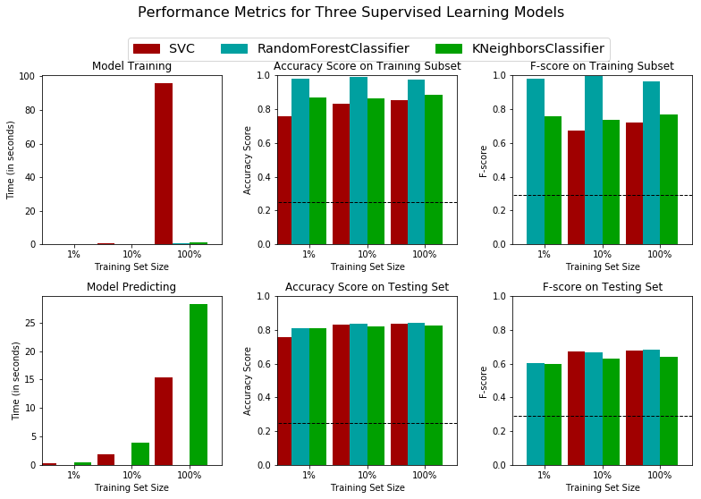

```python
# Importa os três modelos de aprendizado supervisionado da sklearn
from sklearn import svm
from sklearn.neighbors import KNeighborsClassifier
from sklearn.ensemble import RandomForestClassifier
# Inicializa os três modelos
clf_A = svm.SVC(random_state= 5)
clf_B = RandomForestClassifier(random_state = 42)
clf_C = KNeighborsClassifier()

# Calcula o número de amostras para 1%, 10%, e 100% dos dados de treinamento
# samples_100 é todo o conjunto de treinamento e.x.: len(y_train)
# samples_10 é 10% de samples_100
# samples_1 é 1% de samples_100
samples_100 = len(y_train)
samples_10 = int(samples_100 * 10 / 100)
samples_1 = int(samples_100 / 100)

# Coleta os resultados dos algoritmos de aprendizado
results = {}
for clf in [clf_A, clf_B, clf_C]:
    clf_name = clf.__class__.__name__
    results[clf_name] = {}
    for i, samples in enumerate([samples_1, samples_10, samples_100]):
        results[clf_name][i] = \
        train_predict(clf, samples, X_train, y_train, X_test, y_test)

# executa visualização de métricas para os três modelos de aprendizado supervisionados escolhidos
vs.evaluate(results, accuracy, fscore)
```

## Melhorando os resultados

### Descrevendo o modelo nos termos de Layman

RandomForest é um algoritmo que se assemelha a um processo de pesquisa pública, só que com uma pequena diferença. Em uma pesquisa pública normal, todos os pesquisadores vão para a rua entrevistar a população com uma série de perguntas predefinidas de acordo com o objetivo da pesquisa e sem saber que tipo de resposta esperar. No caso da RandomForest, os pesquisadores recebem um conjunto de dados de pessoas com as características mais desejadas e outra lista com parte dos dados da população. Em posse desses dados, os pesquisadores precisam gerar perguntas para cada indivíduo, que devem ser respondidas com SIM/NÃO, a fim de selecionar pessoas do grupo geral com características próximas das pessoas do conjunto de dados desejado.

No fim do processo de pesquisa, cada pesquisador vai informar ao contratante quais pessoas ele selecionou com as características desejadas. O contratante agirá como um sistema "eleitoral", verificando as respostas de cada pesquisador e escolhendo as pessoas que foram eleitas pela maioria dos pesquisadores.

#### Referências:

- http://scikit-learn.org/stable/modules/generated/sklearn.ensemble.RandomForestClassifier.html
- https://en.wikipedia.org/wiki/Random_forest
- https://medium.com/machina-sapiens/o-algoritmo-da-floresta-aleat%C3%B3ria-3545f6babdf8
- https://www.mql5.com/pt/articles/1165
- https://www.vooo.pro/insights/um-tutorial-completo-sobre-a-modelagem-baseada-em-tree-arvore-do-zero-em-r-python/

### Tuning do modelo

```python
# Importar 'GridSearchCV', 'make_scorer', e qualquer biblioteca necessária
from sklearn.grid_search import GridSearchCV
from sklearn.metrics import make_scorer
import numpy as np
# Inicializar o classificador
clf = RandomForestClassifier(random_state = 42)

# Criar a lista de parâmetros para otimizar
parameters =  {
                "min_samples_split" : [2,4,6,8],
                "min_samples_leaf" : [1, 2, 3, 4, 5, 6, 7, 10],
                "criterion": ["gini","entropy"],
                "n_estimators": [13]
              }

# Criar um objeto fbeta_score utilizando make_scorer()
scorer = make_scorer(fbeta_score, beta=0.5)

# Realizar uma busca grid no classificador utilizando o 'scorer' como o método de score no GridSearchCV()
grid_obj = GridSearchCV(clf, parameters, scoring = scorer)

# Adequar o objeto da busca grid como os dados para treinamento e encontrar os parâmetros ótimos utilizando fit()
grid_fit = grid_obj.fit(X_train, y_train)

# Recuperar o estimador
best_clf = grid_fit.best_estimator_

# Realizar predições utilizando o modelo não otimizado e modelar
predictions = (clf.fit(X_train, y_train)).predict(X_test)
best_predictions = best_clf.predict(X_test)
# Reportar os scores de antes e de depois
print("Modelo sem otimização\n------")
print("Accuracy score nos dados de teste: {:.4f}".format(accuracy_score(y_test, predictions)))
print("F-score nos dados de teste: {:.4f}".format(fbeta_score(y_test, predictions, beta = 0.5)))
print("\nModelo Otimizado\n------")
print("Accuracy score nos dados de teste: {:.4f}".format(accuracy_score(y_test, best_predictions)))
print("F-score nos dados de teste: {:.4f}".format(fbeta_score(y_test, best_predictions, beta = 0.5)))
```

```
Modelo sem otimização
------
Accuracy score nos dados de teste: 0.8431
F-score nos dados de teste: 0.6842

Modelo Otimizado
------
Accuracy score nos dados de teste: 0.8593
F-score nos dados de teste: 0.7273
```

### Validação final do modelo

#### Resultados:

| Metric | Unoptimized Model | Optimized Model |
| --- | --- | --- |
| Accuracy Score | 84.31% | 86% |
| F-score | 68.42% | 73% |

## Importância dos atributos

Uma tarefa importante quando realizamos aprendizado supervisionado em um conjunto de dados como os dados do censo que estudamos aqui, é determinar quais atributos fornecem maior poder de predição. Focando no relacionamento entre alguns poucos atributos mais importantes e na label alvo nós simplificamos muito o nosso entendimento do fenômeno, que é a coisa mais importante a se fazer. No caso deste projeto, isso significa que nós queremos identificar um pequeno número de atributos que possuem maior chance de predizer se um indivíduo possui renda anual superior à \$50,000.

Escolha um classificador da scikit-learn (e.x.: adaboost, random forests) que possua o atributo `feature_importance_`, que é uma função que calcula o ranking de importância dos atributos de acordo com o classificador escolhido. Na próxima célula python ajuste este classificador para o conjunto de treinamento e utilize este atributo para determinar os 5 atributos mais importantes do conjunto de dados do censo.

### Questão 6 - Observação da Relevância dos Atributos

Quando Exploramos os dados, vimos que existem treze atributos disponíveis para cada registro nos dados do censo. Destes treze atributos, quais os 5 atributos que você acredita que são os mais importantes para predição e em que ordem você os ranquearia? Por quê?

1. **occupation:** Como estamos tentando prever indivíduos que possui renda anual superior à $50.000, a ocupação profissional facilita a previsão de alguns resultados, levando em consideração o conhecimento sobre a renda medial anual para algumas ocupações.
2. **native-country:** Saber o país de origem junto com a ocupação profissional, já é de grande ajuda para o objetivo de previsão. Outro ponto que pode ser levado em consideração é que alguns países já possuem uma "cultura" de doação, por exemplo, aos Estados Unidos, Irlanda e Nova Zelândia.
3. **capital-gain:** Se o invíduo tem altos ganhos de capital, provavelmente ele será mais propenso a realizar doações.
4. **age:** Pessoas mais novas estão no começo da vida, formando famílias, tendo filhos, ou seja, adquirindo dívidas. É mais provável que uma pessoa com idade maior que 40 anos realize mais doações que um jovem de 20~25 anos.
5. **marital-status:** Acredito que juntar os 4 itens anteriores em um indíduo casado aumenta e muito a probabilidade do invíduo realizar doações para a Charity.

### Extraindo a importância do atributo

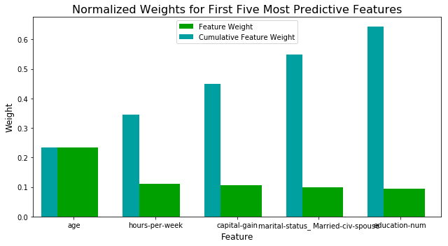

```python
# Treinar o modelo utilizando o conjunto de treinamento com .fit(X_train, y_train)
model = RandomForestClassifier(random_state = 42)
model.fit(X_train, y_train)
# Extrair a importância dos atributos utilizando .feature_importances_
importances = model.feature_importances_

# Plotar
vs.feature_plot(importances, X_train, y_train)
```

Acabei acertando 3 dos 5 atributos mais importantes. Após visualizar as features selecionadas pela RandomForest, percebi que hours-per-week faz mais sentido que native-country, já que estamos procurando pessoas que ganhem mais que $50.000 por ano. Outro ponto que deixei passar, mas após analisar bem faz todo sentido, é o fato da education-num aparecer na lista no lugar de ocupação profissional. Eu acreditava que a ocupação profissional seria mais decisiva para determinar os doadores, mas pessoas com altos níveis de escolaridade nem sempre ocupam o mesmo cargo e ainda assim podem realizar doações.

### Selecionando atributos

Como um modelo performa se nós só utilizamos um subconjunto de todos os atributos disponíveis nos dados? Com menos atributos necessários para treinar, a expectativa é que o treinamento e a predição sejam executados em um tempo muito menor — com o custo da redução nas métricas de performance. A partir da visualização acima, nós vemos que os cinco atributos mais importantes contribuem para mais de 50% da importância de **todos** os atributos presentes nos dados. Isto indica que nós podemos tentar *reduzir os atributos* e simplificar a informação necessária para o modelo aprender. O código abaixo utilizará o mesmo modelo otimizado encontrado anteriormente e treinará o modelo com o mesmo conjunto de dados de treinamento, porém apenas com *os cinco atributos mais importantes*

```python
# Importar a funcionalidade para clonar um modelo
from sklearn.base import clone

# Reduzir a quantidade de atributos
X_train_reduced = X_train[X_train.columns.values[(np.argsort(importances)[::-1])[:5]]]
X_test_reduced = X_test[X_test.columns.values[(np.argsort(importances)[::-1])[:5]]]

# Treinar o melhor modelo encontrado com a busca grid anterior
clf = (clone(best_clf)).fit(X_train_reduced, y_train)

# Fazer novas predições
reduced_predictions = clf.predict(X_test_reduced)

# Reportar os scores do modelo final utilizando as duas versões dos dados.
print("Final Model trained on full data\n------")
print("Accuracy on testing data: {:.4f}".format(accuracy_score(y_test, best_predictions)))
print("F-score on testing data: {:.4f}".format(fbeta_score(y_test, best_predictions, beta = 0.5)))
print("\nFinal Model trained on reduced data\n------")
print("Accuracy on testing data: {:.4f}".format(accuracy_score(y_test, reduced_predictions)))
print("F-score on testing data: {:.4f}".format(fbeta_score(y_test, reduced_predictions, beta = 0.5)))
```

```
Final Model trained on full data
------
Accuracy on testing data: 0.8593
F-score on testing data: 0.7273

Final Model trained on reduced data
------
Accuracy on testing data: 0.8467
F-score on testing data: 0.6960
```

### Efeitos da seleção de atributos

- Como o F-score do modelo final e o accuracy score do conjunto de dados reduzido utilizando apenas cinco atributos se compara aos mesmos indicadores utilizando todos os atributos?
- Se o tempo de treinamento é uma variável importante, você consideraria utilizar os dados enxutos como seu conjunto de treinamento?

**Resposta:** A diferença do F-Score/Accuracy com todas as features e com as 5 melhores features selecionadas é de 0.0313 e 0.0126 respectivamente. Se um dos requisitos for para utilizar o modelo em tempo real, eu aconselharia utilizar o modelo reduzido para não prejudicar a usabilidade do sistema que consumirá esses resultados, mas como sabemos que será utilizado para o envio de cartas, acredito que vale a pena perder um pouco de tempo para ser mais assertivo.